Jacob F. Brumley

# The Data

We will examine the effect of numerous socioeconomic factors related to percentage of children under the age of 18 who are living below the poverty line in the Southern United States. Data for this analysis was collected from the U.S. Census Bureau, American Community Survey, Bureau of Labor Force Statistics, U.S. Department of Agriculture Economic Research Service, and the County Health Rankings. Independent variables include: rural, urban, manufacturing, agriculture, retail, healthcare, construction, less than high school degree, unemployment, income ratio, teen birth, unmarried, single mother, uninsured, as well as race variable like Black and Hispanic.

Specifically wanted to look at the great **Commonwealth of Kentucky**.

```
##      FIPS State     County_Name Longitude Latitude child.pov.2016
## 373 21001    KY    Adair County -85.28814 37.10431           32.7
## 374 21003    KY    Allen County -86.20086 36.75273           23.2
## 375 21005    KY Anderson County -85.00396 38.00387           13.6
## 376 21007    KY  Ballard County -88.99860 37.06000           24.8
## 377 21009    KY   Barren County -85.94213 36.96658           29.9
## 378 21011    KY     Bath County -83.74863 38.14725           30.3
##     unemployment_13 per_lhs_13 per_black_13 per_hispanic_13 per_ag_13
## 373            10.2       26.2     2.455071        1.749037  3.831205
## 374             7.5       23.6     1.262237        1.610098  6.808245
## 375             6.5       12.7     2.604867        1.422943  1.170846
## 376             9.2       15.6     3.513644        1.171215  5.249495
## 377             7.7       20.7     4.164314        2.740919  2.540100
## 378            10.4       26.1     1.585407        1.414934  6.162325
##     per_construction_13 per_manufacturing_13 per_retail_13 per_healthss_13
```

[output cut: 34 more lines]

```
##      FIPS              State           County_Name          Longitude
##  Length:120         Length:120         Length:120         Min.   :-89.17
##  Class :character   Class :character   Class :character   1st Qu.:-86.27
##  Mode  :character   Mode  :character   Mode  :character   Median :-84.88
##                                                           Mean   :-85.21
##                                                           3rd Qu.:-83.91
##                                                           Max.   :-82.39
##     Latitude     child.pov.2016  unemployment_13    per_lhs_13
##  Min.   :36.55   Min.   : 8.20   Min.   : 5.300   Min.   : 8.10
##  1st Qu.:37.11   1st Qu.:23.50   1st Qu.: 7.500   1st Qu.:15.82
##  Median :37.58   Median :28.30   Median : 8.800   Median :21.00
##  Mean   :37.62   Mean   :29.93   Mean   : 9.448   Mean   :21.60
##  3rd Qu.:38.05   3rd Qu.:35.25   3rd Qu.:10.700   3rd Qu.:26.55
##  Max.   :38.97   Max.   :55.30   Max.   :18.200   Max.   :38.60
##   per_black_13     per_hispanic_13   per_ag_13       per_construction_13
##  Min.   : 0.0000   Min.   :0.000   Min.   : 0.2723   Min.   : 2.460
##  1st Qu.: 0.7448   1st Qu.:0.971   1st Qu.: 2.3941   1st Qu.: 5.892
##  Median : 2.4523   Median :1.636   Median : 4.0026   Median : 6.977
##  Mean   : 3.6308   Mean   :2.097   Mean   : 5.4491   Mean   : 7.356
##  3rd Qu.: 4.9281   3rd Qu.:2.725   3rd Qu.: 6.9995   3rd Qu.: 8.363
##  Max.   :23.2782   Max.   :8.981   Max.   :29.8089   Max.   :13.095
##  per_manufacturing_13 per_retail_13    per_healthss_13 per_singlemom_13
##  Min.   : 1.792       Min.   : 5.202   Min.   :15.31   Min.   : 4.447
##  1st Qu.:12.034       1st Qu.:10.378   1st Qu.:20.46   1st Qu.: 8.165
##  Median :16.223       Median :11.723   Median :23.38   Median : 9.905
##  Mean   :16.031       Mean   :11.703   Mean   :23.65   Mean   : 9.720
##  3rd Qu.:21.080       3rd Qu.:13.432   3rd Qu.:25.69   3rd Qu.:11.173
##  Max.   :36.762       Max.   :16.477   Max.   :34.81   Max.   :16.658
##      urban            rural       lnchildpov    lnunemployment
##  Min.   :0.0000   Min.   :0.0   Min.   :2.104   Min.   :1.668
##  1st Qu.:0.0000   1st Qu.:0.0   1st Qu.:3.157   1st Qu.:2.015
##  Median :0.0000   Median :0.0   Median :3.343   Median :2.175
##  Mean   :0.2917   Mean   :0.3   Mean   :3.341   Mean   :2.210
##  3rd Qu.:1.0000   3rd Qu.:1.0   3rd Qu.:3.562   3rd Qu.:2.370
##  Max.   :1.0000   Max.   :1.0   Max.   :4.013   Max.   :2.901
##     lnlesshs        lnblack          lnhispanic           lnag
##  Min.   :2.092   Min.   :-4.8992   Min.   :-4.6052   Min.   :-1.3010
##  1st Qu.:2.762   1st Qu.:-0.2946   1st Qu.:-0.0296   1st Qu.: 0.8729
##  Median :3.045   Median : 0.8970   Median : 0.4919   Median : 1.3869
##  Mean   :3.018   Mean   : 0.5875   Mean   : 0.3708   Mean   : 1.3684
```

[output cut: 8 more lines]

```
##  Max.   :2.5722   Max.   :3.6045   Max.   :2.802   Max.   :3.550
##   lnsinglemom      lnchpov17      lnuninsured    lnincome_ratio
##  Min.   :1.492   Min.   :1.974   Min.   :2.266   Min.   :1.162
##  1st Qu.:2.100   1st Qu.:3.105   1st Qu.:2.793   1st Qu.:1.478
##  Median :2.293   Median :3.321   Median :2.866   Median :1.590
##  Mean   :2.242   Mean   :3.301   Mean   :2.853   Mean   :1.580
##  3rd Qu.:2.413   3rd Qu.:3.548   3rd Qu.:2.942   3rd Qu.:1.681
##  Max.   :2.813   Max.   :4.022   Max.   :3.115   Max.   :1.894
##  lnsevere_housing  lnteenbirth     lnunmarried
##  Min.   :1.921    Min.   :2.740   Min.   :0.010
##  1st Qu.:2.494    1st Qu.:3.799   1st Qu.:3.018
##  Median :2.598    Median :4.004   Median :3.431
##  Mean   :2.584    Mean   :3.956   Mean   :3.214
##  3rd Qu.:2.701    3rd Qu.:4.158   3rd Qu.:3.688
##  Max.   :3.089    Max.   :4.489   Max.   :4.459
```

# Ordinary Least Squares

Created an equation and ran a simple OLS regression.

```r
equation <- child.pov.2016 ~ rural + urban + lnmanufacturing + lnag +
            lnretail + lnhealthss + lnconstruction + lnlesshs +
            lnunemployment + lnsinglemom + lnblack + lnhispanic +
            lnuninsured + lnincome_ratio + lnteenbirth + lnunmarried
options(scipen = 6)
OLS <- lm(equation, data = ky_pov)
summary(OLS)
```

```
##
## Call:
## lm(formula = equation, data = ky_pov)
##
## Residuals:
##      Min       1Q   Median       3Q      Max
## -15.7203  -4.0479   0.0278   3.8008  15.5434
##
## Coefficients:
##                 Estimate Std. Error t value Pr(>|t|)
## (Intercept)     -83.4140    24.8136  -3.362  0.00109 **
## rural             0.9198     1.5843   0.581  0.56280
## urban             1.1785     1.6835   0.700  0.48548
## lnmanufacturing   1.6995     1.5728   1.081  0.28242
## lnag             -0.4139     0.9537  -0.434  0.66518
## lnretail         -1.7800     3.3587  -0.530  0.59729
## lnhealthss        3.7004     4.7166   0.785  0.43452
## lnconstruction    0.9644     2.4640   0.391  0.69632
## lnlesshs         10.7766     4.3340   2.487  0.01451 *
## lnunemployment   11.7755     4.2236   2.788  0.00632 **
## lnsinglemom       1.3482     2.5920   0.520  0.60409
## lnblack           0.3994     0.5298   0.754  0.45265
## lnhispanic       -0.4861     0.7680  -0.633  0.52814
## lnuninsured       0.4240     7.7298   0.055  0.95636
## lnincome_ratio   18.4578     5.8659   3.147  0.00216 **
## lnteenbirth       1.3717     1.9576   0.701  0.48508
## lnunmarried       0.6695     0.6754   0.991  0.32385
## ---
## Signif. codes:  0 '***' 0.001 '**' 0.01 '*' 0.05 '.' 0.1 ' ' 1
##
## Residual standard error: 6.066 on 103 degrees of freedom
## Multiple R-squared:  0.6697, Adjusted R-squared:  0.6184
## F-statistic: 13.06 on 16 and 103 DF,  p-value: < 2.2e-16
```

The model was statistically significant with a p-value of <2.2e-16. There are also significant log variables within the model (less than high school education, unemployment, and income ratio).

# Spatial Regression Analysis

## Contiguity Analysis

Created a list of contiguity neighbors and ran both **Moran’s Correlation and LaGrange Multiplier tests.**

```r
#Moran Correlation Test
lm.morantest(OLS, cont.neighb)
```

```
##
##  Global Moran I for regression residuals
##
## data:
## model: lm(formula = equation, data = ky_pov)
## weights: cont.neighb
##
## Moran I statistic standard deviate = 0.4248, p-value = 0.3355
## alternative hypothesis: greater
## sample estimates:
## Observed Moran I      Expectation         Variance
##     -0.010047617     -0.033348633      0.003008703
```

The Moran’s Correlation Test produced a non-significant p-value of 0.336. Therefore, we would fail to reject the null hypothesis that there is “no spatial correlation in the residuals.” This would suggest that the simple OLS is the best model going forward, and there is no reason to run spatial regression analyses.

> BUUUUUUUUUUTTTTTT… Let’s just say we need to and go through the spatial stuff anyway. OK??

```r
#LaGrange Multiplier Test
lm.LMtests(OLS, cont.neighb, test = "all")
```

```
##
##  Lagrange multiplier diagnostics for spatial dependence
##
## data:
## model: lm(formula = equation, data = ky_pov)
## weights: cont.neighb
##
## LMerr = 0.029109, df = 1, p-value = 0.8645
##
##
##  Lagrange multiplier diagnostics for spatial dependence
##
## data:
## model: lm(formula = equation, data = ky_pov)
## weights: cont.neighb
##
## LMlag = 0.41291, df = 1, p-value = 0.5205
##
##
##  Lagrange multiplier diagnostics for spatial dependence
##
## data:
## model: lm(formula = equation, data = ky_pov)
## weights: cont.neighb
##
## RLMerr = 1.1039, df = 1, p-value = 0.2934
##
##
##  Lagrange multiplier diagnostics for spatial dependence
##
## data:
## model: lm(formula = equation, data = ky_pov)
## weights: cont.neighb
##
## RLMlag = 1.4877, df = 1, p-value = 0.2226
##
##
##  Lagrange multiplier diagnostics for spatial dependence
##
## data:
## model: lm(formula = equation, data = ky_pov)
## weights: cont.neighb
##
## SARMA = 1.5168, df = 2, p-value = 0.4684
```

The results of the five (5) LaGrange Multiplier Tests are as follows:

| LMerr | LMlag | RLMerr | RLMlag | SARMA |
| --- | --- | --- | --- | --- |
| 0.865 | 0.521 | 0.293 | 0.223 | 0.468 |

Since we are throwing out the SARMA and the “robust” variables… We see that out of these ugly numbers that the spatial lag model would be the best out of the spatial regression models. So here we go with everything else!!!

Spatially Lagged X Model

```r
#Spatially Lagged X Model (SLX)
SLX.model <- lmSLX(equation, data = ky_pov, cont.neighb)
summary(SLX.model)
```

```
##
## Call:
## lm(formula = formula(paste("y ~ ", paste(colnames(x)[-1], collapse = "+"))),
##     data = as.data.frame(x), weights = weights)
##
## Residuals:
##      Min       1Q   Median       3Q      Max
## -12.6914  -3.4653  -0.1489   3.2568  13.0524
##
## Coefficients:
##                      Estimate Std. Error t value Pr(>|t|)
## (Intercept)         -109.7084    66.9540  -1.639   0.1049
## rural                  0.7608     1.6319   0.466   0.6422
## urban                  1.2541     1.8188   0.690   0.4923
## lnmanufacturing        5.1971     2.1270   2.443   0.0166 *
## lnag                  -1.9745     1.2866  -1.535   0.1285
## lnretail              -3.1082     3.5329  -0.880   0.3814
## lnhealthss             4.9914     5.3167   0.939   0.3504
## lnconstruction         2.1399     2.5980   0.824   0.4124
## lnlesshs               7.1167     5.0401   1.412   0.1615
## lnunemployment         7.4786     4.6439   1.610   0.1109
## lnsinglemom            1.2710     2.7166   0.468   0.6410
## lnblack                0.5601     0.5507   1.017   0.3119
## lnhispanic            -0.2125     0.8199  -0.259   0.7961
## lnuninsured            9.7656     8.5334   1.144   0.2556
## lnincome_ratio         8.6051     6.2501   1.377   0.1721
## lnteenbirth            0.1760     2.1496   0.082   0.9349
## lnunmarried            0.1862     0.6761   0.275   0.7837
## lag.rural             -1.6456     3.8490  -0.428   0.6700
## lag.urban              0.5945     4.3047   0.138   0.8905
## lag.lnmanufacturing   -3.7505     3.7558  -0.999   0.3208
## lag.lnag               3.7017     2.1779   1.700   0.0928 .
## lag.lnretail           6.0140     7.6849   0.783   0.4360
## lag.lnhealthss        14.0536    11.5807   1.214   0.2282
## lag.lnconstruction    -2.4497     6.3274  -0.387   0.6996
## lag.lnlesshs          24.4500     9.4527   2.587   0.0114 *
## lag.lnunemployment   -18.2714     9.6335  -1.897   0.0612 .
## lag.lnsinglemom        2.8975     6.6855   0.433   0.6658
## lag.lnblack           -2.1816     1.2669  -1.722   0.0886 .
## lag.lnhispanic         1.3699     1.9070   0.718   0.4745
## lag.lnuninsured      -29.7406    21.5118  -1.383   0.1703
## lag.lnincome_ratio    -2.5796    15.4905  -0.167   0.8681
## lag.lnteenbirth        7.1841     5.0536   1.422   0.1587
## lag.lnunmarried        1.2430     1.5386   0.808   0.4213
## ---
## Signif. codes:  0 '***' 0.001 '**' 0.01 '*' 0.05 '.' 0.1 ' ' 1
##
## Residual standard error: 5.746 on 87 degrees of freedom
## Multiple R-squared:  0.7498, Adjusted R-squared:  0.6577
## F-statistic: 8.146 on 32 and 87 DF,  p-value: 3.473e-15
```

```r
summary(impacts(SLX.model, cont.neighb), zstats = TRUE)[["pzmat"]]
```

```
##                     Direct    Indirect        Total
## rural           0.64107756 0.668974350 0.8428731181
## urban           0.49047907 0.890150464 0.6756168568
## lnmanufacturing 0.01455224 0.317995908 0.6663207094
## lnag            0.12485720 0.089203865 0.3495745221
## lnretail        0.37897219 0.433876403 0.7207651772
## lnhealthss      0.34781923 0.224924255 0.1003652448
## lnconstruction  0.41013110 0.698637441 0.9637377210
## lnlesshs        0.15794628 0.009693743 0.0007100422
## lnunemployment  0.10730737 0.057874354 0.3086108169
## lnsinglemom     0.63986835 0.664726801 0.5613784079
## lnblack         0.30910783 0.085072349 0.2458531275
## lnhispanic      0.79550822 0.472549587 0.6050439880
## lnuninsured     0.25245843 0.166810709 0.4099483750
## lnincome_ratio  0.16857625 0.867742617 0.7248509525
## lnteenbirth     0.93475846 0.155151348 0.2134108883
## lnunmarried     0.78306079 0.419139807 0.3836854976
```

Spatial Lag Model

```r
#Spatial Lag Model
sp.lag.model <- spatialreg::lagsarlm(equation, data = ky_pov, cont.neighb)
summary(sp.lag.model, Nagelkerke = TRUE)
```

```
##
## Call:
## spatialreg::lagsarlm(formula = equation, data = ky_pov, listw = cont.neighb)
##
## Residuals:
##       Min        1Q    Median        3Q       Max
## -15.46851  -4.09198  -0.17233   3.81633  15.23065
##
## Type: lag
## Coefficients: (asymptotic standard errors)
##                  Estimate Std. Error z value  Pr(>|z|)
## (Intercept)     -80.14459   23.50267 -3.4100 0.0006496
## rural             0.94507    1.46346  0.6458 0.5184240
## urban             1.15574    1.55514  0.7432 0.4573749
## lnmanufacturing   1.70900    1.45285  1.1763 0.2394728
## lnag             -0.45947    0.88128 -0.5214 0.6021084
## lnretail         -2.26662    3.13872 -0.7221 0.4702048
## lnhealthss        3.00943    4.43138  0.6791 0.4970630
## lnconstruction    1.12212    2.27669  0.4929 0.6221035
## lnlesshs          9.47361    4.18631  2.2630 0.0236357
## lnunemployment   11.64299    3.93347  2.9600 0.0030766
## lnsinglemom       1.13600    2.40368  0.4726 0.6364929
## lnblack           0.47133    0.49202  0.9580 0.3380825
## lnhispanic       -0.46648    0.70990 -0.6571 0.5111110
## lnuninsured       1.46717    7.15975  0.2049 0.8376349
## lnincome_ratio   18.03596    5.43682  3.3174 0.0009087
## lnteenbirth       1.22995    1.81259  0.6786 0.4974169
## lnunmarried       0.69417    0.62509  1.1105 0.2667797
##
## Rho: 0.088667, LR test value: 0.52425, p-value: 0.46903
## Asymptotic standard error: 0.10721
##     z-value: 0.82702, p-value: 0.40822
## Wald statistic: 0.68397, p-value: 0.40822
##
## Log likelihood: -377.1756 for lag model
## ML residual variance (sigma squared): 31.399, (sigma: 5.6035)
## Nagelkerke pseudo-R-squared: 0.67119
## Number of observations: 120
## Number of parameters estimated: 19
## AIC: 792.35, (AIC for lm: 790.88)
## LM test for residual autocorrelation
## test value: 0.66329, p-value: 0.4154
```

```r
summary(impacts(sp.lag.model, listw = cont.neighb, R=100),
        zstats = TRUE)[["pzmat"]]
```

```
##                      Direct  Indirect       Total
## rural           0.631709974 0.7529204 0.629331389
## urban           0.329275694 0.6330353 0.334372526
## lnmanufacturing 0.278945272 0.6201171 0.289388082
## lnag            0.583425940 0.7750240 0.583082090
## lnretail        0.428488457 0.6762466 0.442920943
## lnhealthss      0.480875221 0.7590013 0.486625595
## lnconstruction  0.711893418 0.6976389 0.694863869
## lnlesshs        0.030328025 0.5291624 0.025301997
## lnunemployment  0.004526525 0.4588065 0.005948686
## lnsinglemom     0.778209645 0.8060725 0.772707997
## lnblack         0.307068429 0.5973829 0.319681284
## lnhispanic      0.452531470 0.7547502 0.461240995
## lnuninsured     0.775468899 0.8410020 0.775899712
## lnincome_ratio  0.002186297 0.4620997 0.003547438
## lnteenbirth     0.544292241 0.7158740 0.544517677
## lnunmarried     0.181995186 0.4965054 0.177101440
```

Although this model is more similar to the OLS in terms of significant variables and R<sup>2</sup> / pseudo-R<sup>2</sup>, the model was not significant with a p-value of *0.469*. The significant variables were less than a high school education, unemployment, and income ratio.

Spatial Error Model

```r
#Spatial Error Model
sp.err.model <- spatialreg::errorsarlm(equation, data = ky_pov,
                                       cont.neighb)
summary(sp.err.model, Nagelkerke = TRUE)
```

```
##
## Call:
## spatialreg::errorsarlm(formula = equation, data = ky_pov, listw = cont.neighb)
##
## Residuals:
##       Min        1Q    Median        3Q       Max
## -15.63270  -4.09519   0.15194   3.81585  15.56168
##
## Type: error
## Coefficients: (asymptotic standard errors)
##                   Estimate Std. Error z value  Pr(>|z|)
## (Intercept)     -82.977478  22.773275 -3.6436 0.0002688
## rural             0.902710   1.470256  0.6140 0.5392277
## urban             1.225344   1.553434  0.7888 0.4302305
## lnmanufacturing   1.696154   1.441530  1.1766 0.2393413
## lnag             -0.362306   0.871773 -0.4156 0.6777054
## lnretail         -1.707292   3.102064 -0.5504 0.5820635
## lnhealthss        3.773060   4.340348  0.8693 0.3846836
## lnconstruction    0.881976   2.279082  0.3870 0.6987656
## lnlesshs         11.068628   3.988020  2.7755 0.0055122
## lnunemployment   11.515514   3.904713  2.9491 0.0031867
## lnsinglemom       1.381630   2.395855  0.5767 0.5641589
## lnblack           0.374903   0.489974  0.7651 0.4441826
## lnhispanic       -0.483135   0.712430 -0.6782 0.4976765
## lnuninsured      -0.097282   7.159263 -0.0136 0.9891585
## lnincome_ratio   18.532652   5.416669  3.4214 0.0006230
## lnteenbirth       1.426477   1.815404  0.7858 0.4320062
## lnunmarried       0.678940   0.624390  1.0874 0.2768753
##
## Lambda: -0.039475, LR test value: 0.047508, p-value: 0.82746
## Asymptotic standard error: 0.14315
##     z-value: -0.27576, p-value: 0.78274
## Wald statistic: 0.076041, p-value: 0.78274
##
## Log likelihood: -377.4139 for error model
## ML residual variance (sigma squared): 31.565, (sigma: 5.6183)
## Nagelkerke pseudo-R-squared: 0.66988
## Number of observations: 120
## Number of parameters estimated: 19
## AIC: 792.83, (AIC for lm: 790.88)
```

With the spatial error model, we get the same significant log variables as the OLS(less than high school education, unemployment and income ratio), although the model itself is not significant with a p-value of *0.827*.

[output not shown]

Now we will do a Hausman test.

*Pace, R.K. and LeSage, J.P. (2008) A spatial Hausman test. Economics Letters 101(3), pgs. 282-284*

```r
#Hausman Test
spatialreg:: Hausman.test(sp.err.model)
```

```
##
##  Spatial Hausman test (asymptotic)
##
## data:  NULL
## Hausman test = 8.656, df = 17, p-value = 0.9504
```

The Hausman Test resulted in a highly non-significant p-value of *0.950*. Therefore, we fail to reject the null hypothesis that the spatial error model is an appropriate model.

Spatial Durbin Error Model

```r
sd.err <- spatialreg::errorsarlm(equation, ky_pov, cont.neighb, etype = "emixed")
sdm <- spatialreg::lagsarlm(equation, ky_pov, cont.neighb, type = "mixed")
summary(sd.err, Nagelkerke = TRUE)
```

```
##
## Call:
## spatialreg::errorsarlm(formula = equation, data = ky_pov, listw = cont.neighb,
##     etype = "emixed")
##
## Residuals:
##       Min        1Q    Median        3Q       Max
## -12.24936  -3.49925  -0.32219   3.22467  12.81033
##
## Type: error
## Coefficients: (asymptotic standard errors)
##                       Estimate Std. Error z value  Pr(>|z|)
## (Intercept)         -88.102840  52.356390 -1.6828 0.0924230
## rural                 0.844425   1.365636  0.6183 0.5363522
## urban                 1.130037   1.558264  0.7252 0.4683357
## lnmanufacturing       5.259887   1.849147  2.8445 0.0044482
## lnag                 -2.096468   1.134348 -1.8482 0.0645777
## lnretail             -2.233141   3.029964 -0.7370 0.4611107
## lnhealthss            5.207237   4.622947  1.1264 0.2600008
## lnconstruction        2.278481   2.204046  1.0338 0.3012428
## lnlesshs              7.415685   4.396530  1.6867 0.0916586
## lnunemployment        7.892148   3.977613  1.9841 0.0472400
## lnsinglemom           1.042147   2.329346  0.4474 0.6545871
## lnblack               0.550865   0.470539  1.1707 0.2417145
## lnhispanic           -0.236714   0.688784 -0.3437 0.7310953
## lnuninsured           9.715559   7.162872  1.3564 0.1749791
## lnincome_ratio        9.477514   5.320826  1.7812 0.0748780
## lnteenbirth          -0.011132   1.786129 -0.0062 0.9950274
## lnunmarried           0.104678   0.578762  0.1809 0.8564733
## lag.rural            -1.538173   3.082057 -0.4991 0.6177277
## lag.urban            -0.248386   3.446498 -0.0721 0.9425469
## lag.lnmanufacturing  -3.574849   3.051861 -1.1714 0.2414514
## lag.lnag              3.662538   1.837375  1.9934 0.0462227
## lag.lnretail          4.740066   6.124192  0.7740 0.4389364
## lag.lnhealthss       14.980314   9.652016  1.5520 0.1206527
## lag.lnconstruction   -3.933439   5.045912 -0.7795 0.4356677
## lag.lnlesshs         25.839916   7.673029  3.3676 0.0007582
## lag.lnunemployment  -20.968675   7.748622 -2.7061 0.0068075
## lag.lnsinglemom       2.016852   5.370992  0.3755 0.7072825
## lag.lnblack          -2.116415   0.991711 -2.1341 0.0328341
## lag.lnhispanic        1.357915   1.505886  0.9017 0.3671959
## lag.lnuninsured     -36.221041  17.428928 -2.0782 0.0376897
## lag.lnincome_ratio   -1.530799  12.424362 -0.1232 0.9019412
## lag.lnteenbirth       6.257432   4.088470  1.5305 0.1258913
## lag.lnunmarried       1.522096   1.227030  1.2405 0.2148010
##
## Lambda: -0.26902, LR test value: 2.3792, p-value: 0.12296
## Asymptotic standard error: 0.14888
##     z-value: -1.807, p-value: 0.070764
## Wald statistic: 3.2652, p-value: 0.070764
##
## Log likelihood: -359.6005 for error model
## ML residual variance (sigma squared): 23.142, (sigma: 4.8106)
## Nagelkerke pseudo-R-squared: 0.75468
## Number of observations: 120
## Number of parameters estimated: 35
## AIC: 789.2, (AIC for lm: 789.58)
```

```r
summary(spatialreg::impacts(sd.err, listw = cont.neighb, R = 100), zstats = TRUE)[["pzmat"]]
```

```
##                     Direct     Indirect          Total
## rural           0.53635221 0.6177276658 0.836730762342
## urban           0.46833565 0.9425468571 0.790488531662
## lnmanufacturing 0.00444820 0.2414513730 0.496836216071
## lnag            0.06457773 0.0462227268 0.252870335168
## lnretail        0.46111074 0.4389364093 0.677623651812
## lnhealthss      0.26000085 0.1206526542 0.023491745224
## lnconstruction  0.30124275 0.4356676969 0.744899889684
## lnlesshs        0.09165855 0.0007581756 0.000001170066
## lnunemployment  0.04724004 0.0068075091 0.098024962916
## lnsinglemom     0.65458714 0.7072824903 0.571582858465
## lnblack         0.24171452 0.0328341205 0.126817229838
## lnhispanic      0.73109534 0.3671959110 0.502115778422
## lnuninsured     0.17497910 0.0376896592 0.153438682262
## lnincome_ratio  0.07487796 0.9019412494 0.542540344801
## lnteenbirth     0.99502742 0.1258912647 0.167005561465
## lnunmarried     0.85647329 0.2148010298 0.179817642069
```

The Spatial Durbin Error Model gave us statistically significant values for the variables manufacturing jobs and unemployment and the lags for agriculture jobs, less than high school education, unemployment, African-American, and uninsured. The model was not significant with a p-value of *0.123*.

We ran a few likelihood ratio tests for some of the models.

```
##
##  Likelihood ratio for spatial linear models
##
## data:
## Likelihood ratio = 35.627, df = 16, p-value = 0.003259
## sample estimates:
##       Log likelihood of sd.err Log likelihood of sp.err.model
##                      -359.6005                      -377.4139
```

```
##
##  Likelihood ratio for spatial linear models
##
## data:
## Likelihood ratio = 2.3792, df = 1, p-value = 0.123
## sample estimates:
##    Log likelihood of sd.err Log likelihood of SLX.model
##                   -359.6005                   -360.7900
```

```
##
##  Likelihood ratio for spatial linear models
##
## data:
## Likelihood ratio = 35.674, df = 17, p-value = 0.005068
## sample estimates:
## Log likelihood of sd.err    Log likelihood of OLS
##                -359.6005                -377.4377
```

From these likelihood raio tests, we see that we should not restrict the models to either the spatial error model or the OLS. But we can restrict the model to the SLX.

## K-Nearest Neighbors Analysis

We created centroids and lists of neighbors.

Distance Lag Model

```r
#Distance Lag Model
all.dist.lag.k1 <- lagsarlm(equation, data = ky_pov, listw = all.dist.neighb.k1)
all.dist.lag.k3 <- lagsarlm(equation, data = ky_pov, listw = all.dist.neighb.k3)
all.dist.lag.k5 <- lagsarlm(equation, data = ky_pov, listw = all.dist.neighb.k5)
summary(all.dist.lag.k1, Nagelkerke = TRUE)
```

```
##
## Call:spatialreg::lagsarlm(formula = formula, data = data, listw = listw,
##     na.action = na.action, Durbin = Durbin, type = type, method = method,
##     quiet = quiet, zero.policy = zero.policy, interval = interval,
##     tol.solve = tol.solve, trs = trs, control = control)
##
## Residuals:
##        Min         1Q     Median         3Q        Max
## -15.457997  -4.153543  -0.083926   3.816454  15.006869
##
## Type: lag
## Coefficients: (asymptotic standard errors)
##                  Estimate Std. Error z value  Pr(>|z|)
## (Intercept)     -78.65355   23.33174 -3.3711 0.0007487
## rural             0.88094    1.45763  0.6044 0.5456037
## urban             1.16164    1.54898  0.7499 0.4532929
## lnmanufacturing   1.66827    1.44691  1.1530 0.2489153
## lnag             -0.48295    0.87732 -0.5505 0.5819851
## lnretail         -2.65239    3.12541 -0.8487 0.3960736
## lnhealthss        2.86289    4.36457  0.6559 0.5118639
## lnconstruction    1.16689    2.26653  0.5148 0.6066689
## lnlesshs          8.97862    4.07179  2.2051 0.0274485
## lnunemployment   11.45413    3.96639  2.8878 0.0038795
## lnsinglemom       0.91082    2.39238  0.3807 0.7034128
## lnblack           0.47509    0.48906  0.9714 0.3313298
## lnhispanic       -0.43046    0.70698 -0.6089 0.5426105
## lnuninsured       1.95504    7.11445  0.2748 0.7834712
## lnincome_ratio   18.15522    5.40303  3.3602 0.0007789
## lnteenbirth       1.21398    1.80734  0.6717 0.5017768
## lnunmarried       0.69772    0.62144  1.1227 0.2615479
##
## Rho: 0.11757, LR test value: 1.2808, p-value: 0.25775
## Asymptotic standard error: 0.092574
##     z-value: 1.27, p-value: 0.20409
## Wald statistic: 1.6129, p-value: 0.20409
##
## Log likelihood: -376.7973 for lag model
## ML residual variance (sigma squared): 31.132, (sigma: 5.5796)
## Nagelkerke pseudo-R-squared: 0.67325
## Number of observations: 120
## Number of parameters estimated: 19
## AIC: 791.59, (AIC for lm: 790.88)
## LM test for residual autocorrelation
## test value: 0.34248, p-value: 0.5584
```

Distance Error Model

```r
all.dist.err.k1 <- errorsarlm(equation, data = ky_pov, listw = all.dist.neighb.k1)
all.dist.err.k3 <- errorsarlm(equation, data = ky_pov, listw = all.dist.neighb.k3)
all.dist.err.k5 <- errorsarlm(equation, data = ky_pov, listw = all.dist.neighb.k5)
summary(all.dist.err.k1, Nagelkerke = TRUE)
```

```
##
## Call:
## spatialreg::errorsarlm(formula = formula, data = data, listw = listw,
##     na.action = na.action, Durbin = Durbin, etype = etype, method = method,
##     quiet = quiet, zero.policy = zero.policy, interval = interval,
##     tol.solve = tol.solve, trs = trs, control = control)
##
## Residuals:
##        Min         1Q     Median         3Q        Max
## -15.948603  -3.962550  -0.015963   3.898860  15.488217
##
## Type: error
## Coefficients: (asymptotic standard errors)
##                  Estimate Std. Error z value  Pr(>|z|)
## (Intercept)     -83.98480   23.23000 -3.6154 0.0002999
## rural             0.90327    1.46221  0.6177 0.5367421
## urban             1.09176    1.56704  0.6967 0.4859871
## lnmanufacturing   1.69864    1.47670  1.1503 0.2500223
## lnag             -0.46951    0.89795 -0.5229 0.6010671
## lnretail         -1.97428    3.11628 -0.6335 0.5263823
## lnhealthss        3.57137    4.39188  0.8132 0.4161172
## lnconstruction    1.10053    2.28769  0.4811 0.6304713
## lnlesshs         10.23419    4.04215  2.5319 0.0113457
## lnunemployment   12.19539    3.91085  3.1183 0.0018187
## lnsinglemom       1.20943    2.40787  0.5023 0.6154685
## lnblack           0.41750    0.49194  0.8487 0.3960592
## lnhispanic       -0.47932    0.70965 -0.6754 0.4993980
## lnuninsured       1.23549    7.15397  0.1727 0.8628875
## lnincome_ratio   18.43354    5.45621  3.3785 0.0007290
## lnteenbirth       1.37981    1.81017  0.7623 0.4459086
## lnunmarried       0.66914    0.62848  1.0647 0.2870208
##
## Lambda: 0.049892, LR test value: 0.13417, p-value: 0.71415
## Asymptotic standard error: 0.11669
##     z-value: 0.42757, p-value: 0.66897
## Wald statistic: 0.18281, p-value: 0.66897
##
## Log likelihood: -377.3706 for error model
## ML residual variance (sigma squared): 31.53, (sigma: 5.6152)
## Nagelkerke pseudo-R-squared: 0.67012
## Number of observations: 120
## Number of parameters estimated: 19
## AIC: 792.74, (AIC for lm: 790.88)
```

This model is non-significant with a p-value of *0.714*. However, there are significant log variables: less than high school education, unemployed, and income ratio.

When we compare the two distance models, we get:

| Distance | Lag | Model | Distance | Err | Model |
| --- | --- | --- | --- | --- | --- |
| *R<sup>2</sup>* | *p-value* | *AIC* | *R<sup>2</sup>* | *p-value* | *AIC* |
| 0.673 | 0.258 | 791.59 | 0.670 | 0.714 | 792.74 |

Neither model is a great fit for our data.

# Mapping Data

We will now map the results of our data for Kentucky.

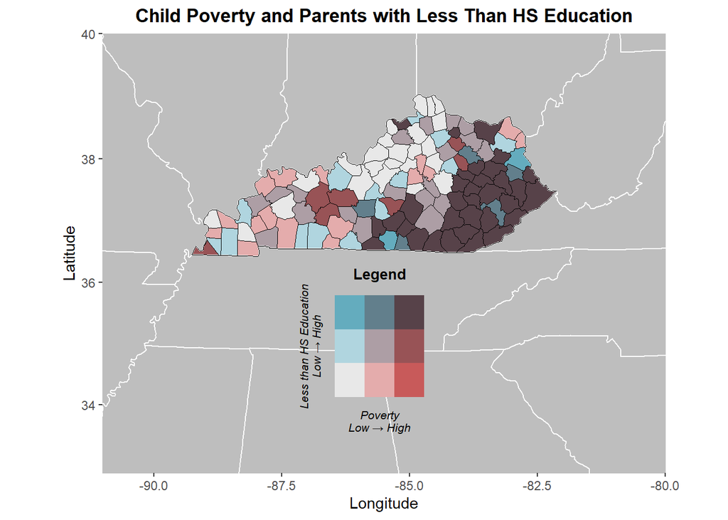